# Classifcation for Mobile Price Range with Machine Learning (231 Final Project)

Bochen Wang

2022-11-17

# Introduction:

## Goal:

The goal of this project is to predict the price range of a certain phone type by classification. There are four price range that matches this part that is from Low price to medium price to high price and vary high. Phone prices are one reason what we consider whether to purchase this phone or not. My dataset is from the Kaggle data set which is about the phone price range. This dataset is from 3 years ago that still using 4g and 3g connection.

## Loading Packages and Environment:

```r
library(corrplot)  # for the correlation plot
library(corrr)   # for calculating correlation
library(knitr)   # to help with the knitting process
library(MASS)    # to assist with the markdown processes
library(tidyverse)   # using tidyverse and tidymodels for this project mostly
library(tidymodels)
library(ggplot2)   # for most of our visualizations
library(ggrepel)
library(rpart.plot)  # for visualizing trees
library(vip)         # for variable importance
library(janitor)     # for cleaning out our data
library(randomForest)   # for building our randomForest
library(stringr)    # for matching strings
library("dplyr")     # for basic r functions
library("yardstick") # for measuring certain metrics
library(ggpubr)
tidymodels_prefer()
options(scipen = 9999)
```

Lets first begin loading our data from the csv file:

```r
phone <- read.csv("D:/1/code/pstat131/train.csv")
```

Lets see how many observation we will be working on.

```r
dim(phone)
```

```
## [1] 2000   21
```

Lets also get a peek of the data:

```r
head(phone)
```

```
##   battery_power blue clock_speed dual_sim fc four_g int_memory m_dep mobile_wt
## 1           842    0         2.2        0  1      0          7   0.6       188
## 2          1021    1         0.5        1  0      1         53   0.7       136
## 3           563    1         0.5        1  2      1         41   0.9       145
## 4           615    1         2.5        0  0      0         10   0.8       131
## 5          1821    1         1.2        0 13      1         44   0.6       141
## 6          1859    0         0.5        1  3      0         22   0.7       164
##   n_cores pc px_height px_width  ram sc_h sc_w talk_time three_g touch_screen
## 1       2  2        20      756 2549    9    7        19       0            0
## 2       3  6       905     1988 2631   17    3         7       1            1
## 3       5  6      1263     1716 2603   11    2         9       1            1
## 4       6  9      1216     1786 2769   16    8        11       1            0
## 5       2 14      1208     1212 1411    8    2        15       1            1
## 6       1  7      1004     1654 1067   17    1        10       1            0
##   wifi price_range
## 1    1           1
## 2    0           2
## 3    0           2
## 4    0           2
## 5    0           1
## 6    0           1
```

I will put what each variable means here that illustrate the function of each variable. variable names Code Book: battery_power: Total energy a battery can store in one time measured in mAh. blue: Has bluetooth or not. clock_speed: speed at which microprocessor executes instructions. dual_sim: Has dual sim support or not. fc: Front Camera mega pixels. four_g: Has 4G or not. int_memory: Internal Memory in Gigabytes. m_dep: Mobile Depth in cm. mobile_wt: mobile_wt. n_cores: Number of cores of processor. pc: Primary Camera mega pixels. px_height: Pixel Resolution Height. px_width: Pixel Resolution Width. ram: Random Access Memory in Megabytes. sc_h: Screen Height of mobile in cm. sc_w: Screen Width of mobile in cm. talk_time: longest time that a single battery charge will last when you are talking. three_g: Has 3G or not. touch_screen: Has touch screen or not. wifi: has wifi or not. price_range: This is the target variable with value of 0(low cost), 1(medium cost), 2(high cost) and 3(very high cost).

# Exploratory Data Analysis

The data choosen is from 3 years ago that might be a bit old. We have certain code book for the variables explaining the names. However, this dataset has many observation and catigorical value already dummy encoded so I ease the process but I decide to make it to factor and dummy encode it in our recipe.

changing the categorical data to factors:

```r
phone$blue <- as.factor(phone$blue)
phone$dual_sim <- as.factor(phone$dual_sim)
phone$four_g <- as.factor(phone$four_g)
phone$three_g <- as.factor(phone$three_g)
phone$touch_screen <- as.factor(phone$touch_screen)
phone$wifi <- as.factor(phone$wifi)
phone$price_range <- as.factor(phone$price_range)
```

Correlation plots:

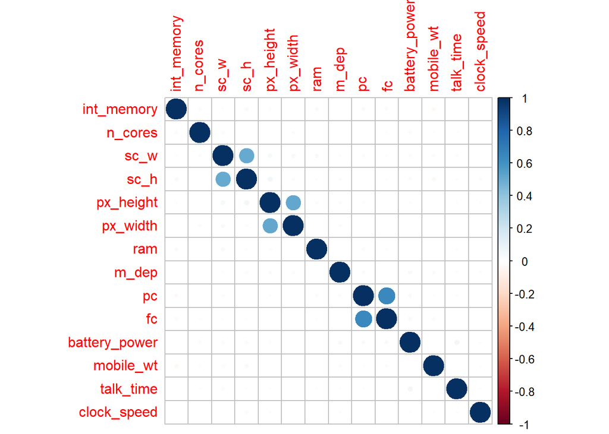

```r
phone_numer <- phone %>%  # getting just the numeric data
  select_if(is.numeric)

phone_cor <- cor(phone_numer)  # calculating the correlation between each variable
phone_cor_plot <- corrplot(phone_cor,  # making the correlation plot
                               order = 'AOE')
```

I am surprised that there are little correlation between the varibles. The screen height and the screen width are connected with one another because their screen size are basically related to this. Also, the front camara pixels and primary camare pixiels are correlated because the varibles are related to each other by the different parameter of pixel size. It is the samefor pixel width and height. So we might want to explore each varible’s relation and distribution with the response parameter in our later EDA.

## Response - Phone Price Range:

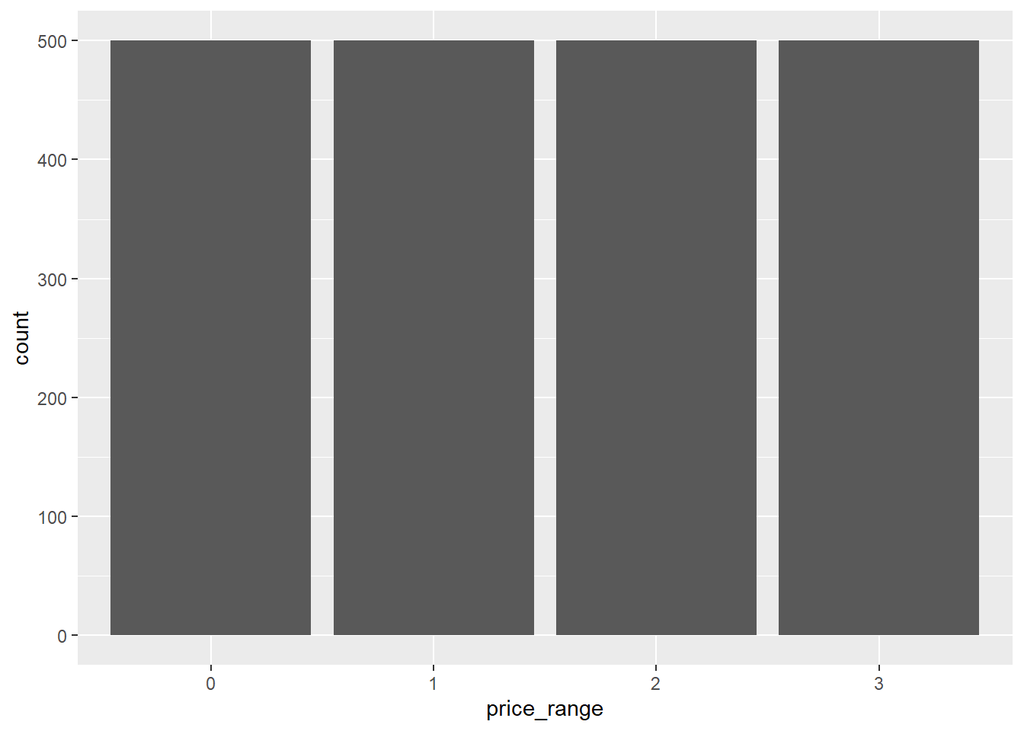

```r
phone %>%
  ggplot(aes(x = price_range)) +
  geom_bar()
```

We can see that the data we have chosen is equally distributed in the four price range that we can use the reasonable stratified sampling for getting the training set later.

## Battery Power:

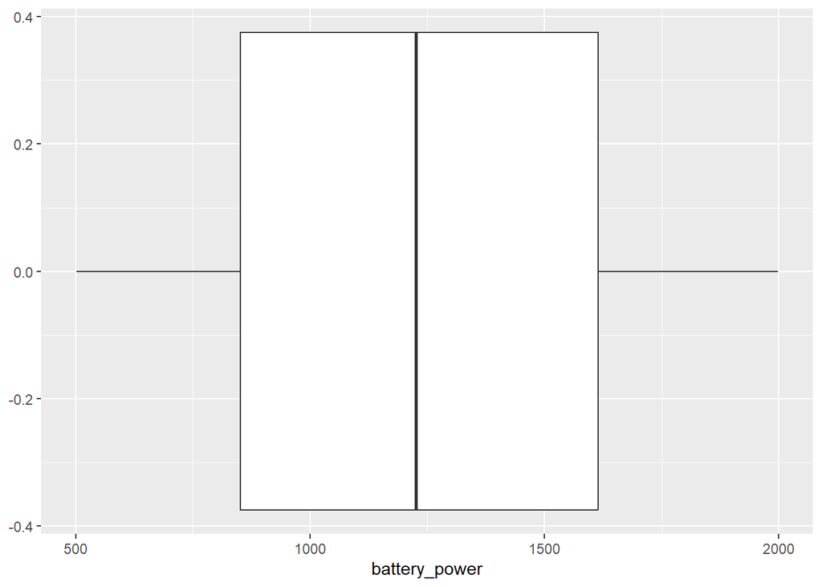

```r
ggplot(phone, aes(battery_power)) +
  geom_boxplot()
```

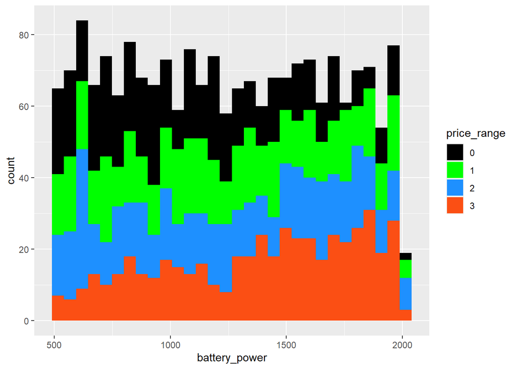

```r
ggplot(phone, aes(battery_power)) +
  geom_histogram(aes(fill = price_range)) +
  scale_fill_manual(values = c("#000000", "#00FF00",    "#1E90FF","#FB4F14"))
```

We can see distictively here that higher price range phones tend to have higher better power. In the latter part, I will examine the talk_time relation with the battery power to see if they have some thing in common.

## Bluetooth:

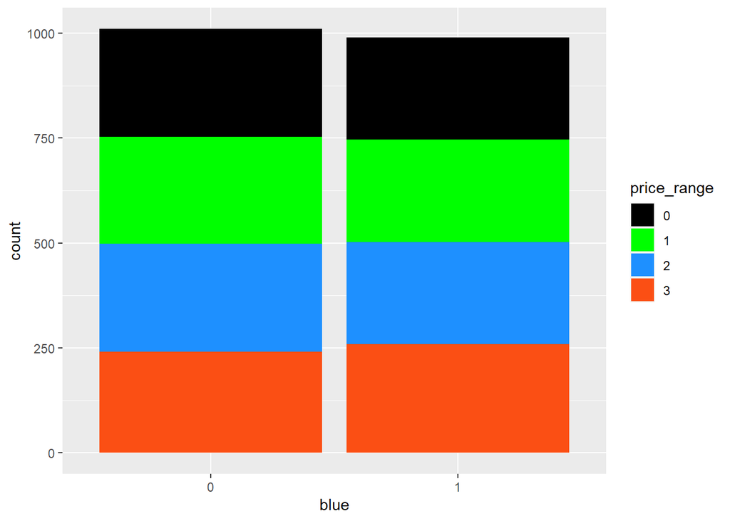

```r
ggplot(phone, aes(blue)) +
  geom_bar(aes(fill = price_range)) +
  scale_fill_manual(values = c("#000000", "#00FF00",    "#1E90FF","#FB4F14"))
```

It seems like the data set has collected equally amount of blue tooth for each price range. So I think this variable is not so good for recognition of price range becasue it does not have specific distributions.

## Clock speed:

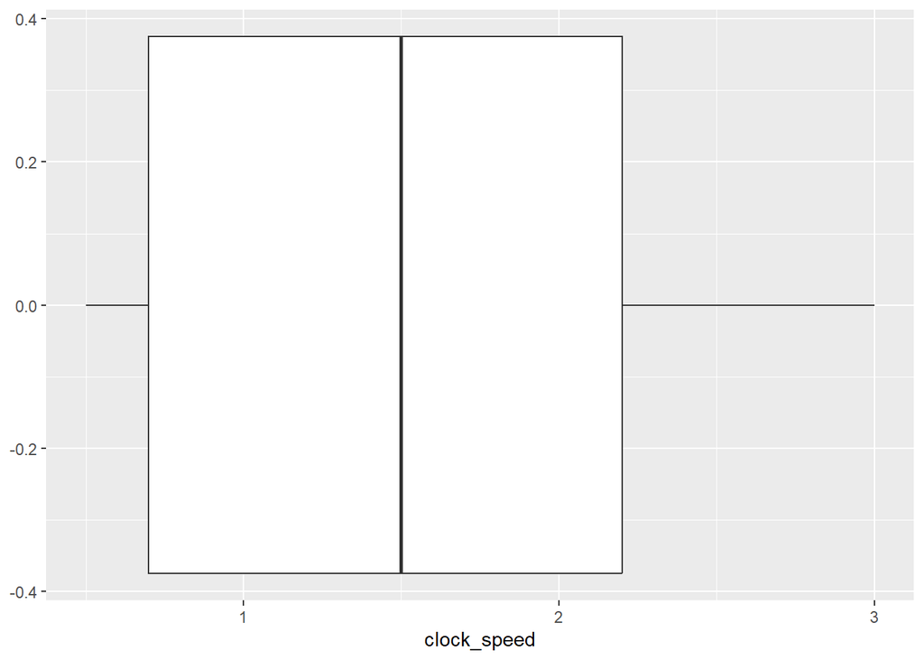

```r
ggplot(phone, aes(clock_speed)) +
  geom_boxplot()
```

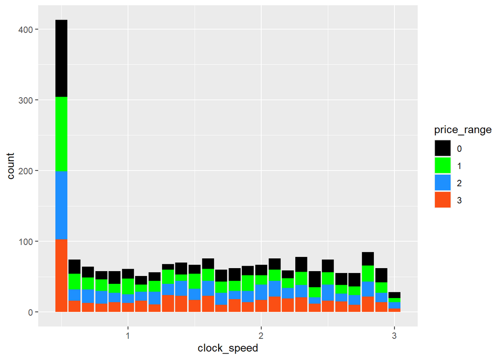

```r
ggplot(phone, aes(clock_speed)) +
  geom_bar(aes(fill = price_range)) +
  scale_fill_manual(values = c("#000000", "#00FF00",    "#1E90FF","#FB4F14"))
```

We can see that mostly the clock speed is higher has fewer observations. This distribution is different at each level of clock_speed so it can be a distinctive factor for recognizing the price ranges.

## Int Memory:

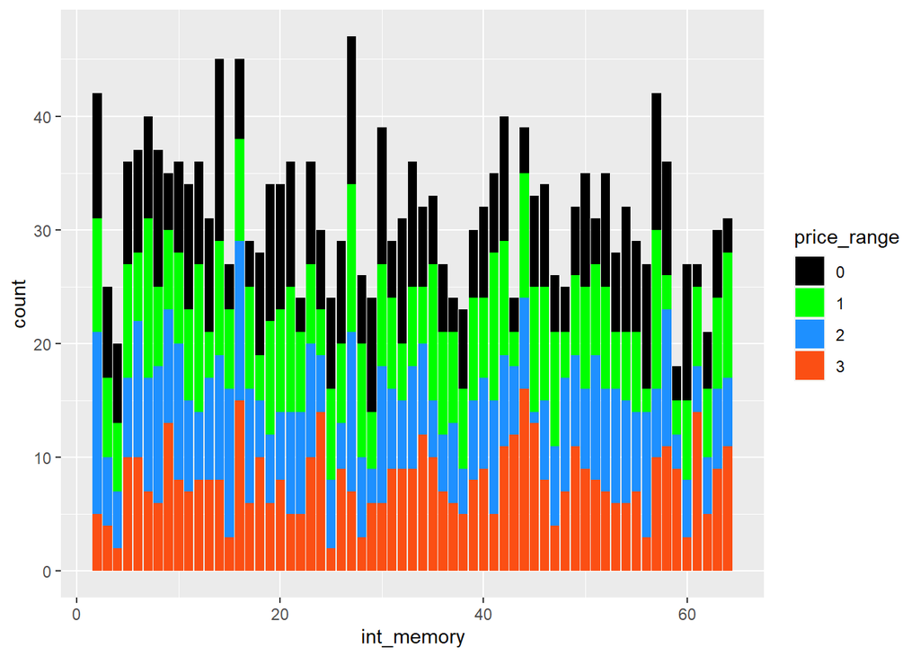

```r
ggplot(phone, aes(int_memory)) +
  geom_bar(aes(fill = price_range)) +
  scale_fill_manual(values = c("#000000", "#00FF00",    "#1E90FF","#FB4F14"))
```

we can say that lower price range have lower memory stored. There are distinctive features here about the distribution and we can examine with vip function to see which variables are more important than the other.

## Pixels discovery:

I want to see how does pixel width and height related to each other

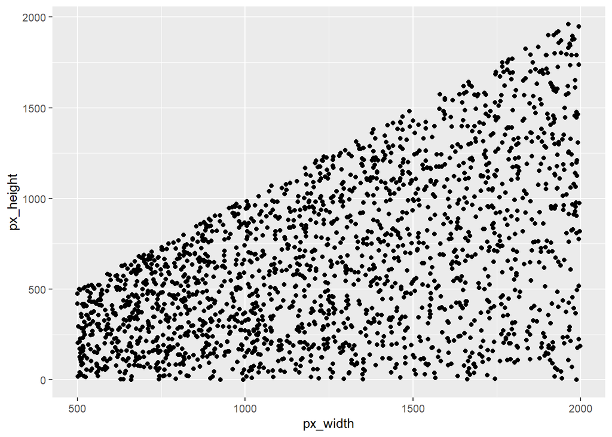

```r
phone %>%
  ggplot(aes(x = px_width, y = px_height)) +
  geom_point()
```

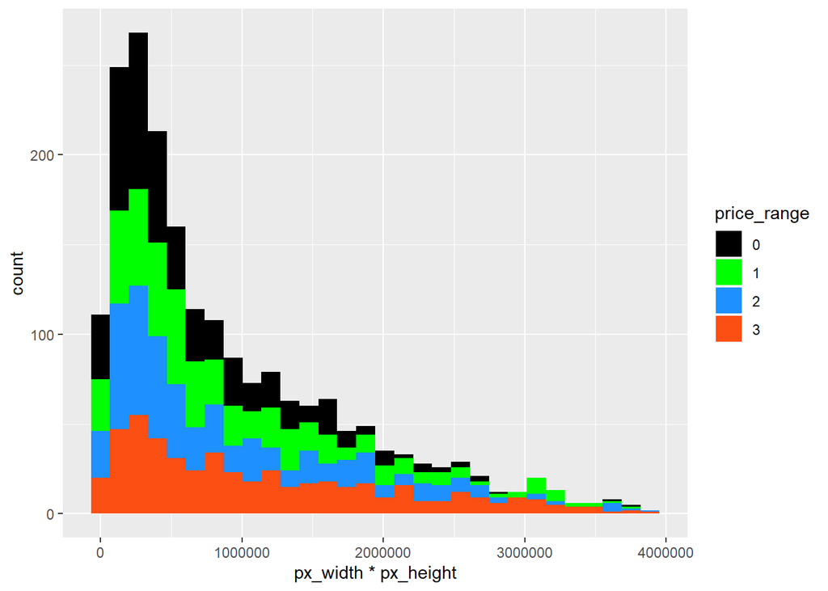

```r
ggplot(phone, aes(px_width*px_height)) +
  geom_histogram(aes(fill = price_range)) +
  scale_fill_manual(values = c("#000000", "#00FF00",    "#1E90FF","#FB4F14"))
```

I created the scatter plot between the two variables and use the multpied version of the two with their results beening that most phone’s pixels are reletively low but we can use their correlation for extraction of features.

## Touch Screen and Price:

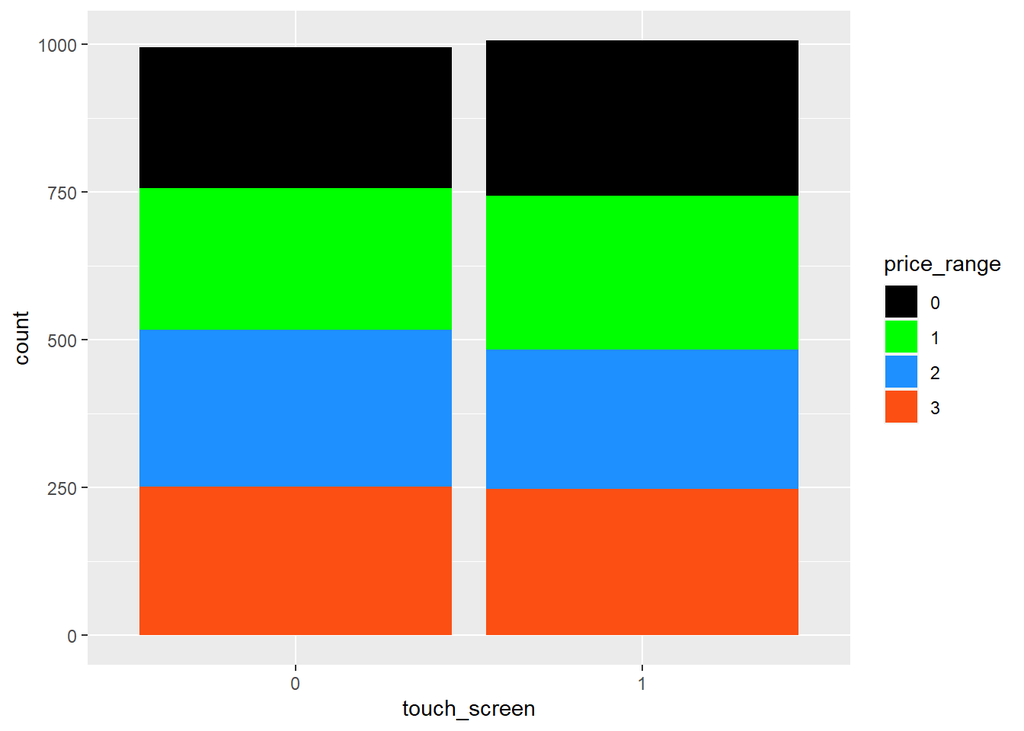

```r
ggplot(phone, aes(touch_screen)) +
  geom_bar(aes(fill = price_range)) +
  scale_fill_manual(values = c("#000000", "#00FF00",    "#1E90FF","#FB4F14"))
```

I dont see there is much of a difference that make us to differ from the price range.

## Camaras:

The front camera and primary camera are correlated and I want to see how they are relating to each other.

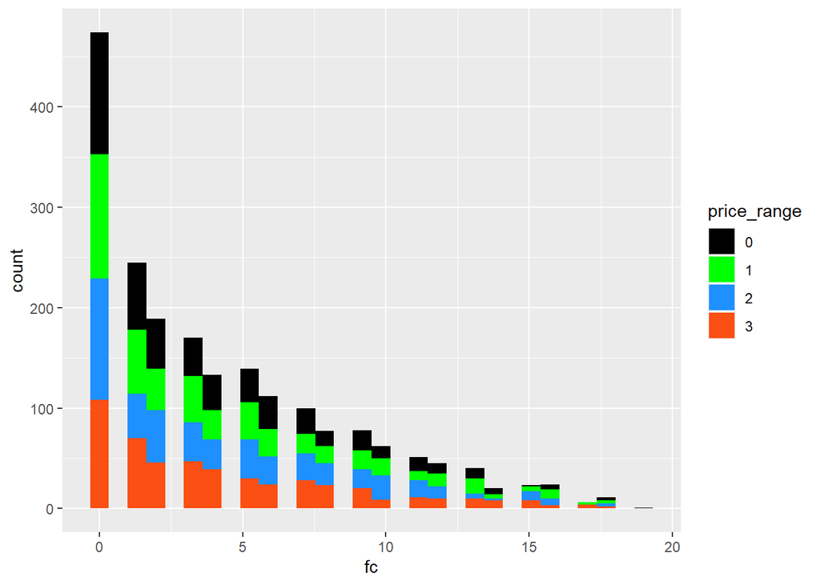

```r
ggplot(phone, aes(fc)) +
  geom_histogram(aes(fill = price_range)) +
  scale_fill_manual(values = c("#000000", "#00FF00",    "#1E90FF","#FB4F14"))
```

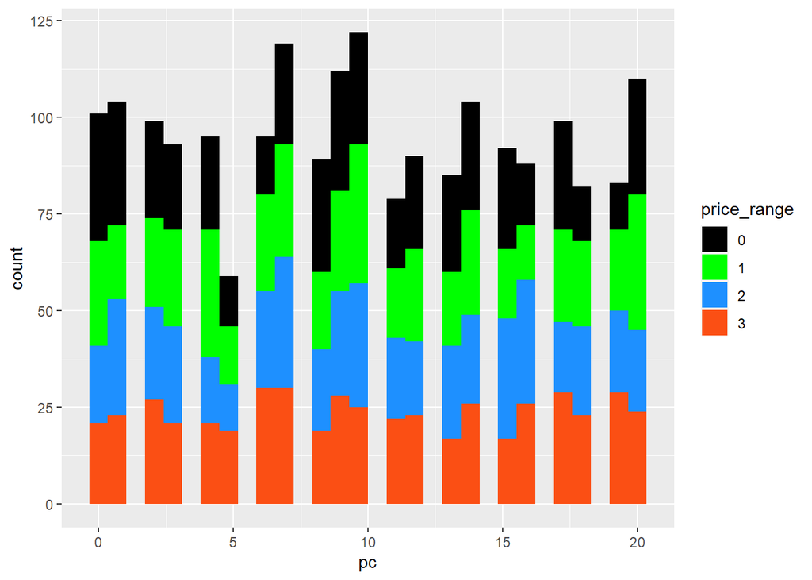

```r
ggplot(phone, aes(pc)) +
  geom_histogram(aes(fill = price_range)) +
  scale_fill_manual(values = c("#000000", "#00FF00",    "#1E90FF","#FB4F14"))
```

We can see that they depend on the fc variable more than pc variable. Their combined features can be important for differencing the distinction.

## RAM and Cores:

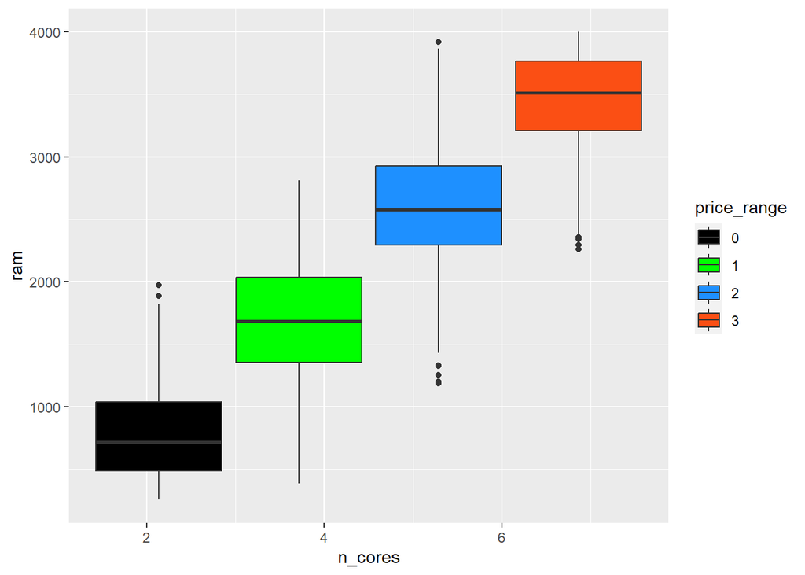

```r
phone %>%
  ggplot() +
    geom_boxplot(mapping=aes(x = n_cores, y = ram, fill = price_range)) +
    scale_fill_manual(values = c("#000000", "#00FF00",  "#1E90FF","#FB4F14"))
```

We can see that with increased prices their ram and number of processors are also increasing. So these two variables are vary important in classifying the price ranges of the mobile.

## Talk time, Bettery and Price:

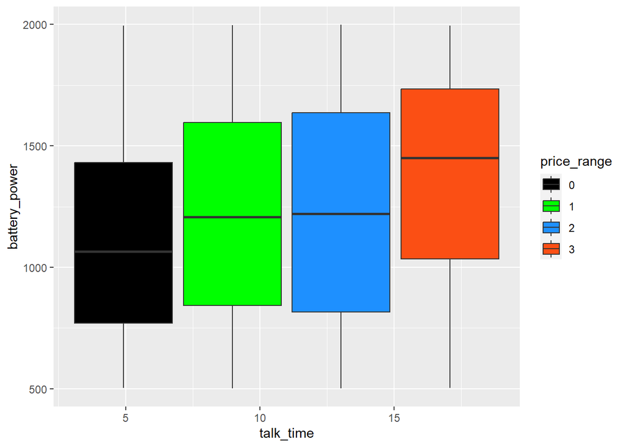

```r
phone %>%
  ggplot() +
    geom_boxplot(mapping=aes(x = talk_time, y = battery_power, fill = price_range)) +
    scale_fill_manual(values = c("#000000", "#00FF00",  "#1E90FF","#FB4F14"))
```

There is not so much going on with talk time and battery power maybe because the talk time for low price phones are shorter even if their battery power is the same.

## Data Morphying:

I decided to add the combined value after the EDA of the px_width and px_height’s multiplication, so I decided to add a column of their multiplied values in the data and use it as a predictor.

```r
phone <- phone %>%
  mutate(px_size = px_width * px_height)
```

# Pre-Modelling:

## Train and test spliting:

Here I choose to split the data into 80/20 that we can have a reasonable amount of testing and training sets.

```r
set.seed(2500)  # setting a seed for reproducible results
phone_split <- phone %>%
  initial_split(prop = 0.8, strata = "price_range")

phone_train <- training(phone_split) # training split
phone_test <- testing(phone_split) # testing split
```

Let’s check the testing and training data:

```r
dim(phone_train)
```

```
## [1] 1600   22
```

```r
dim(phone_test)
```

```
## [1] 400  22
```

We can see that they have been successfully splited into the training sets and testing sets.

We want to use k-folds for the cross validation of our data: I am using 5-fold that can run a bit faster on the different models

```r
train_folds <- vfold_cv(phone_train, v = 5, strata = price_range)  # 5-fold CV
```

## Recipe Building:

I will use the correlated variable with fc and pc, and I am including the width*height for their correlation.

```r
phone_recipe <-   # building the recipe to be used for each model
  recipe(price_range ~ battery_power + blue + clock_speed + dual_sim +
           four_g + fc + pc + int_memory + m_dep + mobile_wt + n_cores +
           ram + talk_time + three_g + touch_screen + wifi + px_size,
         data = phone) %>%
  step_impute_linear(clock_speed) %>%
  step_impute_linear(m_dep) %>%
  step_dummy(all_nominal_predictors()) %>%
  step_interact(terms=~fc:pc) %>%
  step_center(all_predictors()) %>%   # standardizing predictors
  step_scale(all_predictors())
```

# Model Building

For my models, I am going to use lasso regression, boosted tree, random forest and KNN models for my classification problem. I use the r scripts to build the model and use the r work space to load the data that I will not to run the modelling process whenever I knit it. I will specify the step I am building and plot the results of our model’s performance. The metric I used to assess my model is by ROC_AUC of the tuned performance. This essentially calculates the area under the curve for the receiver operating characteristic (ROC) curve, which highlights the trade-off between sensibility and sensitivity.

### Steps for Model Building

1. Setting up the models and engines spec
2. Set up a workflow and add the recipe and the model
3. Setting the tuning grid with the parameters that we want tuned, and levels of tuning
4. Tune the model with the parameters of choice
5. Select the most accurate model from all of the tuning, finalize the workflow with those tuning parameters
6. Fit that model with workflow to the training data set
7. Save our results to an RDA file and load it here so that I do not need to wait for it to knit again.

### Code Specs

Here I included the code I use for building the model specs, which is also included in the submitted folder.

```r
#lasso spec
phone_lasso_spec <-
  multinom_reg(penalty = tune(), mixture = tune()) %>%
  set_engine("glmnet")

lasso_workflow <- workflow() %>%
  add_recipe(phone_recipe) %>%
  add_model(phone_lasso_spec)

penalty_grid <- grid_regular(penalty(range = c(-5, 5)), mixture(range=c(0,1)),
                             levels = 5)
penalty_grid

tune_res_lasso <- tune_grid(
  lasso_workflow,
  resamples = train_folds,
  grid = penalty_grid
)
autoplot(tune_res_lasso)

best_penalty<-select_best(tune_res_lasso,metrix="roc_auc")
best_penalty

lasso_final<-finalize_workflow(lasso_workflow,best_penalty)

lasso_final_fit <- fit(lasso_final, data = phone_train)


#boosted tree spec
boost_spec <- boost_tree() %>%
  set_engine("xgboost") %>%
  set_mode("classification")

boost_wf <- workflow() %>%
  add_model(boost_spec %>% set_args(trees = tune())) %>%
  add_recipe(phone_recipe)

tune_grid_boost <- grid_regular(trees(range=c(5,30)), levels = 5)

tune_res_boost <- tune_grid(
  boost_wf,
  resamples = train_folds,
  grid = tune_grid_boost,
  metrics = metric_set(roc_auc)
)

autoplot(tune_res_boost)

boost_preformance <- collect_metrics(tune_res_boost)

arrange(boost_preformance, desc(mean))

final_boost <- select_best(tune_res_boost, metric = "roc_auc")

final_wf_boost <- finalize_workflow(boost_wf, final_boost)

final_fit_boost <- fit(final_wf_boost, data = phone_train)

#rand spec
library(ranger)
rand_for <- rand_forest() %>%
  set_engine("ranger", importance = "impurity")
rand_for_spec <- rand_for %>%
  set_mode("classification")
rand_for_wf <- workflow() %>%
  add_model(rand_for_spec %>% set_args(mtry = tune())
            %>% set_args(trees = tune()) %>%
              set_args(min_n = tune())) %>%
  add_recipe(phone_recipe)
param_grid_rand <- grid_regular(mtry(range = c(1, 18)),trees(range = c(1,10)),
                             min_n(range = c(1, 10)),levels = 5)

tune_res_rand <- tune_grid(
  rand_for_wf,
  resamples = train_folds,
  grid = param_grid_rand,
  metrics = metric_set(roc_auc)
)
autoplot(tune_res_rand)

best_rand<-select_best(tune_res_rand,metrix="roc_auc")
best_rand

rand_final<-finalize_workflow(rand_for_wf, best_rand)

rand_final_fit <- fit(rand_final, data = phone_train)


#KNN spec
KNN_spec <-nearest_neighbor() %>%
  set_mode("classification") %>%
  set_engine("kknn") %>%
  set_args(neighbors = tune())

translate(KNN_spec)

KNN_workflow <- workflow() %>%
  add_recipe(phone_recipe) %>%
  add_model(KNN_spec)

knn_params <- parameters(KNN_spec)

knn_grid <- grid_regular(knn_params, levels = 5)

tune_res_knn <- tune_grid(
  KNN_workflow,
  resamples = train_folds,
  grid = knn_grid
  # control = tune::control_resamples(save_pred = TRUE)
)

autoplot(tune_res_knn)

KNN_roc <- collect_metrics(tune_res_knn) %>%
  dplyr::select(.metric, mean, std_err)

KNN_roc

best_knn<-select_best(KNN_roc,metrix="roc_auc")
best_knn

knn_final<-finalize_workflow(KNN_workflow, best_knn)

knn_final_fit <- fit(knn_final, data = phone_train)
```

# Model Results

Since I am using the four models, I choose my tune grid for as shown in the code specs chunk. I will load my results from RDATA files so that I can compare the best models’ performance with roc_auc that we can use it to fit the model.

```r
load("D:/1/code/pstat131/231models/lasso.RData")
load("D:/1/code/pstat131/231models/boost.RData")
load("D:/1/code/pstat131/231models/rand_forest.RData")
load("D:/1/code/pstat131/231models/KNN.RData")
```

## Model’s Autoplots

### Lasso Penalty Plot

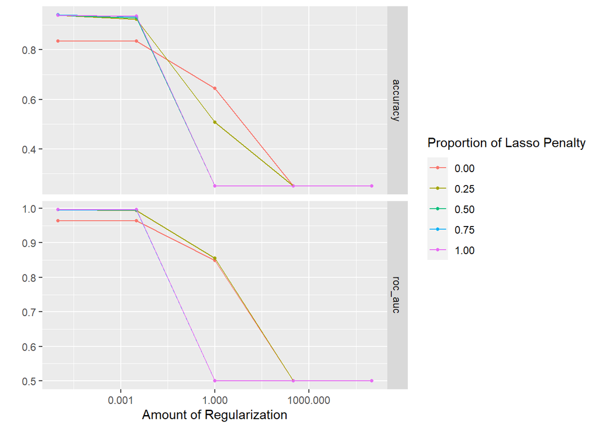

```r
autoplot(tune_res_lasso)
```

### Boosted Tree Autoplot:

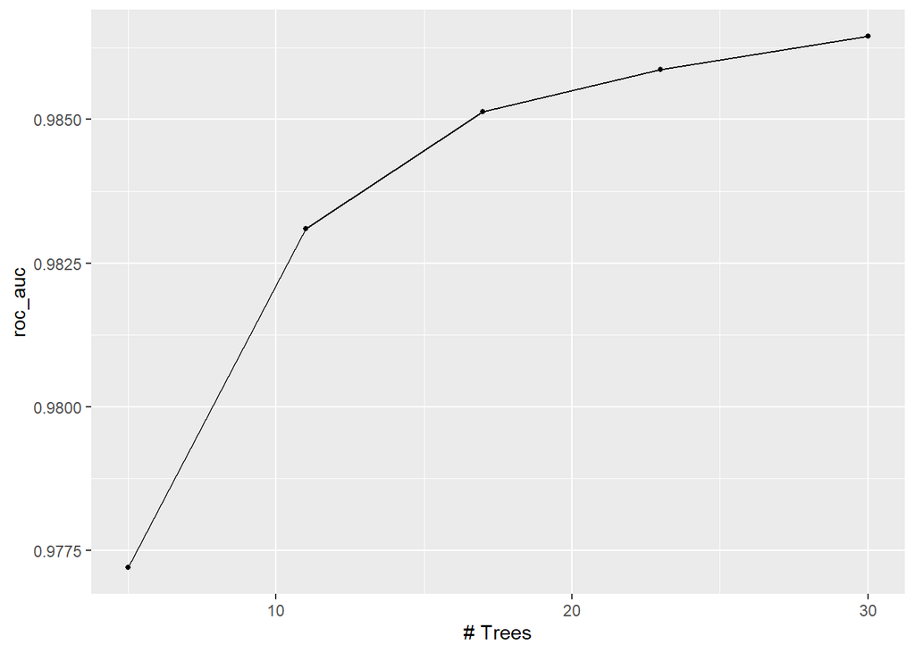

```r
autoplot(tune_res_boost)
```

### Random Forest Autoplots:

We can see from the graph that the model seem to preform well with higher node size and number of trees.

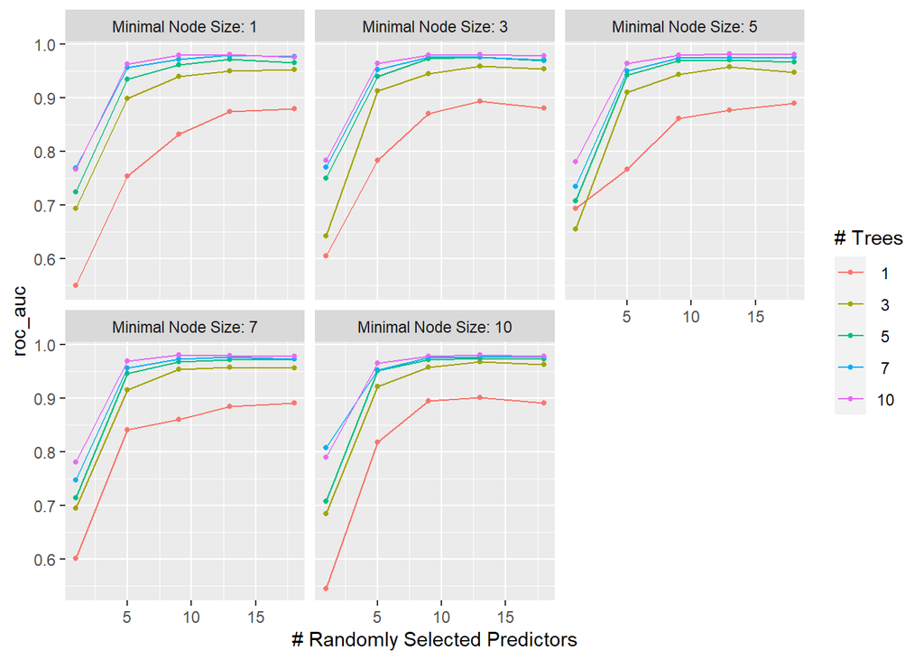

```r
autoplot(tune_res_rand)
```

### K Nearest Neighbor Autoplots:

We can see that with nearest neighbor increasing, the curve is also increasing. However, the overall roc_auc did not perform so well compared to the other models.

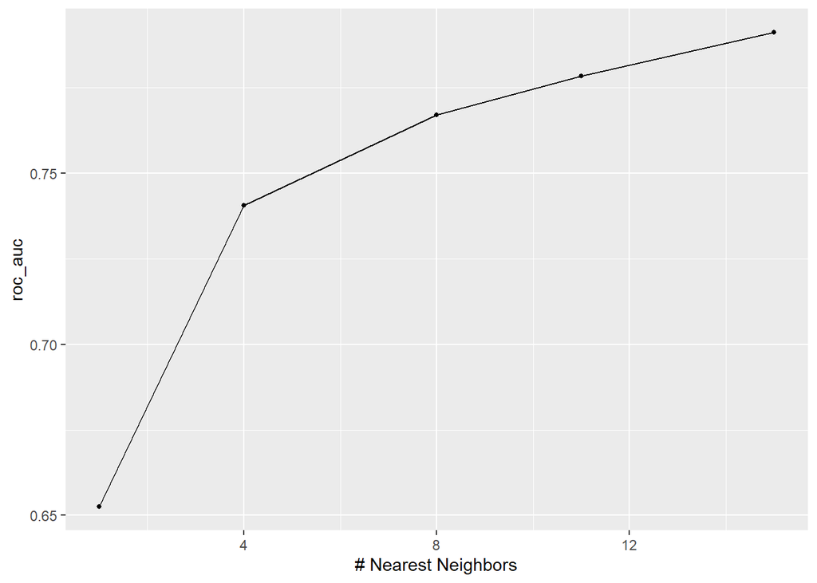

```r
autoplot(tune_res_knn, metric = "roc_auc")
```

## Model Accuracy

I have use the roc_auc score for the fitting on the training data, and here I have created the table for the roc score and it seems that we even have a perfect roc_auc score on the boosted trees. I want to test the model on both the random forest and the boosted tree on the ttesting set because I want to see if my data is overfitting.

```r
tune_lasso_roc <- augment(lasso_final_fit, new_data = phone_train) %>%
  roc_auc(price_range,.pred_0,.pred_1, .pred_2, .pred_3) %>%
  select(.estimate)

tune_boost_roc <- augment(final_fit_boost, new_data = phone_train) %>%
  roc_auc(price_range,.pred_0,.pred_1, .pred_2, .pred_3) %>%
  select(.estimate)
tune_rand_roc <- augment(rand_final_fit, new_data = phone_train) %>%
  roc_auc(price_range,.pred_0,.pred_1, .pred_2, .pred_3) %>%
  select(.estimate)

tune_knn_roc <- augment(knn_final_fit, new_data = phone_train) %>%
  roc_auc(price_range,.pred_0,.pred_1, .pred_2, .pred_3) %>%
  select(.estimate)

model_roc <- c(tune_lasso_roc$.estimate,
                tune_boost_roc$.estimate,
                tune_rand_roc$.estimate,
                tune_knn_roc$.estimate)

phone_mod_names <- c(
            "Lasso",
            "Boosted Tree",
            "Random Forest",
            "K-Nearest Neighbor")
model_results <- tibble(Model = phone_mod_names,
                        roc_auc = model_roc)

model_results <- model_results %>%
  arrange(-model_roc)

model_results
```

```
## # A tibble: 4 × 2
##   Model              roc_auc
##   <chr>                <dbl>
## 1 Boosted Tree         1
## 2 Random Forest        1.00
## 3 Lasso                0.997
## 4 K-Nearest Neighbor   0.968
```

### Create a bar plot of the proformance of the models on the data

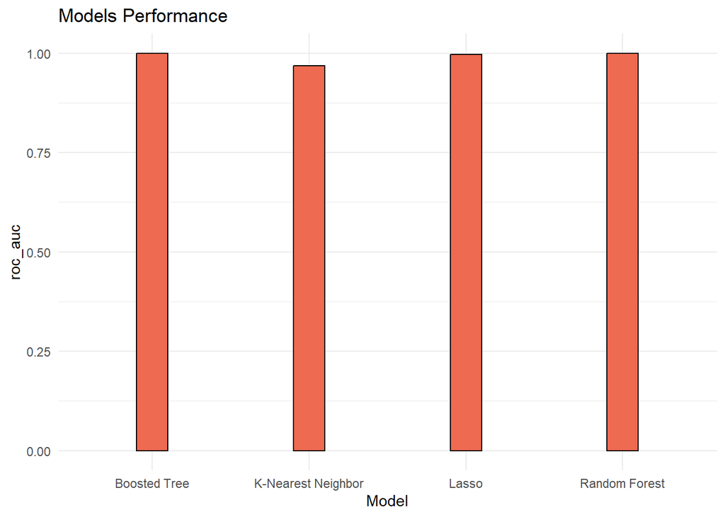

```r
phone_bar_plot <- ggplot(model_results,
       aes(x = Model, y = roc_auc)) +
  geom_bar(stat = "identity", width=0.2, fill = "coral2", color = "black") +
  labs(title = "Models Performance") +
  theme_minimal()

phone_bar_plot
```

I just want to say that the four models all performed vary well here with our data. I want to fit them all on the testing data and see how it goes for all. Of course, I am using the best model of the selected ones.

## Best Model Results

Here I will fit the final best models on our testing sets to see how the model is working under the testing validation set.

### Fitting the Models to our testing set:

```r
#lasso predict and roc curve
lasso_pre <- predict(lasso_final_fit,new_data=phone_test,type="class")

test_auc_lasso<-augment(lasso_final_fit,new_data=phone_test) %>%
  roc_auc(price_range,.pred_0,.pred_1, .pred_2, .pred_3) %>%
  select(.estimate)

test_acc_lasso<-augment(lasso_final_fit,new_data=phone_test) %>%
  accuracy(truth=price_range,estimate=.pred_class)

lasso_roc_curve <- augment(lasso_final_fit,new_data=phone_test) %>%
  roc_curve(price_range,.pred_0,.pred_1, .pred_2, .pred_3)  # computing the ROC curve for this model

lasso_graph <- autoplot(lasso_roc_curve)

#boosted tree predict and roc curve and accuracy
boost_pre <- predict(final_fit_boost,new_data=phone_test,type="class")

test_auc_boost<-augment(final_fit_boost,new_data=phone_test) %>%
  roc_auc(price_range,.pred_0,.pred_1, .pred_2, .pred_3) %>%
  select(.estimate)

test_acc_boost<-augment(final_fit_boost,new_data=phone_test) %>%
  accuracy(truth=price_range,estimate=.pred_class)

boost_roc_curve <- augment(final_fit_boost,new_data=phone_test) %>%
  roc_curve(price_range,.pred_0,.pred_1, .pred_2, .pred_3)  # computing the ROC curve for this model

boost_graph <- autoplot(boost_roc_curve)

#random forest predict and roc curve
rand_pre <- predict(rand_final_fit,new_data=phone_test,type="class")

test_auc_rand<-augment(rand_final_fit,new_data=phone_test) %>%
  roc_auc(price_range,.pred_0,.pred_1, .pred_2, .pred_3) %>%
  select(.estimate)

test_acc_rand<-augment(rand_final_fit,new_data=phone_test) %>%
  accuracy(truth=price_range,estimate=.pred_class)

rand_roc_curve <- augment(rand_final_fit,new_data=phone_test) %>%
  roc_curve(price_range,.pred_0,.pred_1, .pred_2, .pred_3)  # computing the ROC curve for this model

rand_graph <- autoplot(rand_roc_curve)

#knn predict and roc curve
knn_pre <- predict(knn_final_fit,new_data=phone_test,type="class")

knn_auc_rand<-augment(knn_final_fit,new_data=phone_test) %>%
  roc_auc(price_range,.pred_0,.pred_1, .pred_2, .pred_3) %>%
  select(.estimate)

knn_acc_rand<-augment(knn_final_fit,new_data=phone_test) %>%
  accuracy(truth=price_range,estimate=.pred_class)

knn_roc_curve <- augment(knn_final_fit,new_data=phone_test) %>%
  roc_curve(price_range,.pred_0,.pred_1, .pred_2, .pred_3)  # computing the ROC curve for this model

knn_graph <- autoplot(knn_roc_curve)
```

### Plot the graphs of four models roc curve:

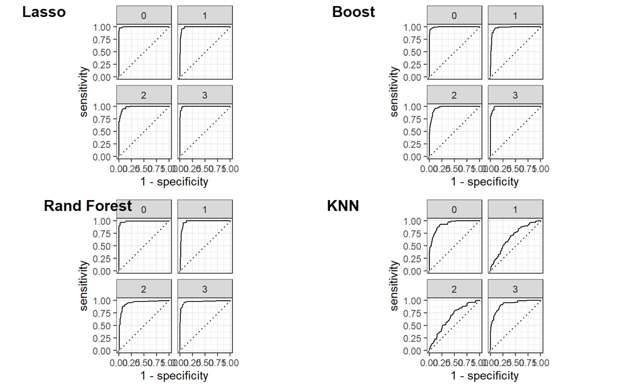

```r
ggarrange(lasso_graph, boost_graph, rand_graph,knn_graph,
                    labels = c("Lasso", "Boost","Rand Forest","KNN"),
                    ncol = 2, nrow = 2)
```

From the roc curve we can see that the KNN performs poorly and lasso seems to be the best choice. And also for the predictions, the prediction about the 2 price range is not so good in every model comparing it to the other type of predictions.

### Plot the graph of their ROC_AUC on the testing set

```r
result_roc <- c(test_auc_lasso$.estimate,
                test_auc_boost$.estimate,
                test_auc_rand$.estimate,
                knn_auc_rand$.estimate)

phone_mod_names <- c(
            "Lasso",
            "Boosted Tree",
            "Random Forest",
            "K-Nearest Neighbor")
model_results_test <- tibble(Model = phone_mod_names,
                        roc_auc = result_roc)

model_results_test <- model_results_test %>%
  arrange(-result_roc)

model_results_test
```

```
## # A tibble: 4 × 2
##   Model              roc_auc
##   <chr>                <dbl>
## 1 Lasso                0.991
## 2 Boosted Tree         0.983
## 3 Random Forest        0.972
## 4 K-Nearest Neighbor   0.798
```

Here we can clearly see that we have lasso as the best to the testing set. Becuase out models did fairly for all the predictions, I will choose lasso as the final model for its roc_auc score not varying too much. I am afraid the the boosted tree will be the overfitting model for that but in this level their roc_auc score did not vary much so that our choice of model is not so relevant to what we choose.

### Plot the accuracy for the models on the testing sets

```r
result_acc <- c(test_acc_lasso$.estimate,
                test_acc_boost$.estimate,
                test_acc_rand$.estimate,
                knn_acc_rand$.estimate)

modacc_results_test <- tibble(Model = phone_mod_names,
                        Accuracy = result_acc)

modacc_results_test <- modacc_results_test %>%
  arrange(-result_acc)

modacc_results_test
```

```
## # A tibble: 4 × 2
##   Model              Accuracy
##   <chr>                 <dbl>
## 1 Lasso                 0.91
## 2 Boosted Tree          0.885
## 3 Random Forest         0.86
## 4 K-Nearest Neighbor    0.54
```

After checking the accuracy, I am pretty sure about using the lasso regression as our final model since my data is not that complicated and I should use the model which is simpler than the tree based models.

## Model Prediction

### We have choose the lasso as our final object and we shoold see how this model preform on newly collected data besides the training and testing data

```r
lasso_final_fit
```

```
## ══ Workflow [trained] ══════════════════════════════════════════════════════════
## Preprocessor: Recipe
## Model: multinom_reg()
##
## ── Preprocessor ────────────────────────────────────────────────────────────────
## 6 Recipe Steps
##
## • step_impute_linear()
## • step_impute_linear()
## • step_dummy()
## • step_interact()
## • step_center()
## • step_scale()
##
## ── Model ───────────────────────────────────────────────────────────────────────
##
## Call:  glmnet::glmnet(x = maybe_matrix(x), y = y, family = "multinomial",      alpha = ~0.5)
##
##     Df  %Dev  Lambda
## 1    0  0.00 0.61680
## 2    1  2.17 0.56200
## 3    1  4.34 0.51210
## 4    1  6.42 0.46660
## 5    1  8.43 0.42520
## 6    1 10.35 0.38740
## 7    1 12.19 0.35300
## 8    1 13.96 0.32160
## 9    1 15.66 0.29300
## 10   1 17.28 0.26700
## 11   1 18.85 0.24330
## 12   1 20.34 0.22170
## 13   1 21.91 0.20200
## 14   1 23.70 0.18400
## 15   1 25.41 0.16770
## 16   2 27.21 0.15280
## 17   3 29.05 0.13920
## 18   3 30.98 0.12690
## 19   3 32.84 0.11560
## 20   3 34.71 0.10530
## 21   3 36.51 0.09596
```

[output cut: 13 more lines]

```
## 35   7 56.95 0.02609
## 36   7 58.22 0.02377
## 37   7 59.46 0.02166
## 38  10 60.68 0.01973
## 39  10 61.86 0.01798
## 40  13 63.02 0.01638
## 41  13 64.15 0.01493
## 42  13 65.25 0.01360
## 43  14 66.32 0.01239
## 44  15 67.36 0.01129
## 45  15 68.38 0.01029
## 46  15 69.36 0.00938
##
## ...
## and 54 more lines.
```

### Let us use this model for a little prediction

Here I put 10 randomly selected new observations in a csv file that contains the outcomes, we can use it for the model accuracy predicting. I have use the imput file here for our new predictions.

```r
phone_new <- read.csv("D:/1/code/pstat131/new.csv")
phone_new <- phone_new %>%
  mutate(px_size = px_width * px_height)

phone_new$blue <- as.factor(phone_new$blue)
phone_new$dual_sim <- as.factor(phone_new$dual_sim)
phone_new$four_g <- as.factor(phone_new$four_g)
phone_new$three_g <- as.factor(phone_new$three_g)
phone_new$touch_screen <- as.factor(phone_new$touch_screen)
phone_new$wifi <- as.factor(phone_new$wifi)
phone_new$price_range <- as.factor(phone_new$price_range)
```

Now, we can use the lasso_final_fit to predict our collected new data, lets see the results.

```r
pred_new <- predict(lasso_final_fit, phone_new, type = "class")

results <- tibble(Prediction = pred_new$.pred_class,
                        Actual = phone_new$price_range)

results
```

```
## # A tibble: 10 × 2
##    Prediction Actual
##    <fct>      <fct>
##  1 2          2
##  2 1          1
##  3 0          0
##  4 2          2
##  5 3          3
##  6 2          1
##  7 3          3
##  8 0          0
##  9 2          2
## 10 1          1
```

Here we observed that our model did a good job at predicting this newly collected phone data. We can see that there is a prediction about the price range at a 2 level but it is actually at level 1 which correspond to our findings in the testing set that our model did not predict the price range at level 2 vary well, so I am fine with the results here that I predicted.

# Concludsion

In our research about the phone prices, we have used the method of data analysis, researching of the dataset, finding the best model that fit our data, we have achieved some understanding of the phone price range classification problem. I think that my model did a fairly job in predicting the ranges of the phone prices. However, there is still a lot of things that needed to be improved here. I can use the more advanced method such as the SVM to build more powerful models. I did not do it because my computer can not behave well in fitting a lot of folds and observations. There is also the problem of over-fitting that needs to be examined in our boosted trees model because I find that with fewer observations that more trees will create the problem of over fitting the data.

In a word, I think my model did a fair job and provide me with some beginner’s experience in the machine learning area. I think later on I will definitely study more in this area and improve my model’s performance.